# 07. 베이즈 최적화

## 07.01. 베이즈 최적화 (Bayes Optimization)

- 베이즈 최적화는 어떤 미지의 함수 $f(x)$를 최대로 하는 솔루션 $x^* = arg max_{x \in X}f(x)$를 구하는 문제
- 대상이 되는 함수 $f(x)$의 평가에 비용이 소요되기에, 최소한의 평갓값밖에 얻을 수 없음을 가정하는 것이 특징
- 대상으로 하는 함수에 대한 가정도 최소한으로 하여 어떤 솔루션 $x$에 대한 평갓값만 주어진다고 가정
- 평가함수의 기울기, 미분정보도 필요하지 않으며, 평갓값에 산포가 존재하더라도 다룰 수 있음

#### 문제설정

1. **에이전트는 각 시점 $t$에서 솔루션 공간 $X$로부터 솔루션 하나를 선택 (선택된 솔루션은 $x_t \in X$)**
2. **에이전트는 평갓값의 기댓값 함수 $f(x_t)$로부터 평갓값 $r_t$를 추출**

   **이때 평갓값은 다음과 같은 정규분포를 따르는 것으로 가정**

$$r_t \sim N(f(x_t), \sigma^2)$$

3. **이 상태에서 최소한의 평가횟수로 기댓값을 최대로 하는 최적 솔루션 $x^* = arg max_{x\in X}f(x)$를 발견하는 것을 목표로 함**
- **웹최적화라는 문맥에서, 솔루션 공간 $X$는 시험할 디자인안 전체, 솔루션 $x_t$는 $t$번째에 방문한 사용자에게 표시한 디자인안, 평갓값 $r_t$는 해당 사용자로부터 얻은 반응(클릭여부, 체류시간 등)**
- **이때 기댓값 함수 $f(x)$는 사용자 반응의 기댓값을 나타내므로, 보상 기댓값 $\theta_x$에 해당하며, 웹최저고하에서는 디자인안 고유의 클릭률에 해당**
- **최소한의 평가횟수로 이 함숫값을 최대로 하는 솔루션을 찾아내는 것은 베이즈 최적화의 관점에서 최소한의 사용자 수로 사용자 반응의 기댓값을 최대로 하는 디자인안을 발견하기 위해 동작하는 것**

  **또한, 기댓값 함수 $f(x)$에 관해서 어떠한 정보도 가지고 있지 않음 (블랙박스 함수)**
  - RGB 색상의 최적화 문제는 색공간 자체가 솔루션 공간이므로 차원수는 3, RGB의 조합 (=색)은 솔루션 $x$에 해당

    이 중에서 클릭률 $f(x)$를 최대로 하는 색 $x$를 탐색하는 것이 목적

## 07.02. 가우스 과정 (Gaussian Process)

- **기댓값 함수의 값 $f(x)$를 최대로 하는 솔루션 $x^*$를 추정해야 하지만, 함수에 관한 어떠한 지식을 가지고 있지 않을때 가우스 과정 사용**

#### 확률과정

- 한개의 입력값 $x$와 예측하려는 출력값 $y$사이에, $f(x)$가 $y$값을 결정하는 숨겨진 함수라고 가정

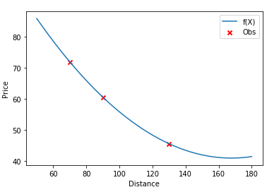

- 함수 $f$는 실제로는 존재하지만, 이에 대한 어떠한 정보가 없으며, $x$의 관측값들만 가지고 있는 상황

  $\rightarrow$ 관측값들로부터 함수 $f$를 예측함으로서, 새로운 $x'$가 들어왔을 때 $y'$를 정확하게 추측하는 것이 회귀의 목표
- **가우스 과정의 특징은 $f(x)$의 결과가 $x$에 따라 특정한 $y$로만 결정되어 있다고 보지 않고 (Non Deterministic)**

  **일정한 확률적 임의성 (Stochastic Randomness)를 갖는다고 봄**
- **이미 관측값이 있는 지점에서는 관측값을 확실하게 얻어낼 수 있지만, 다른 $x$ 값들에 대해서는 함수 $f$가 각 $x$마다 각기 다른 가우스 분포를 따르게 됨**
  - 예) $f(x=50)$이 하나의 가우스 분포를, $f(x=100)$일 때 또다른 가우스 분포를 가짐

  $\rightarrow$ **새로운 $x'$이 주어졌을 때, 딱 하나의 예측값인 $y=\mu$를 결과로 내는 것이 아니라, 가우스 분포의 분산을 통하여 예측범위를 나타냄**

  $\rightarrow$ **즉, 모든 입력 $x$에 대한 함숫값이 $f(x)$라고 하면, 함수 $f$를 또다른 확률변수로 간주**

  $\rightarrow$ 하나의 입력값 $x_*$에 대한 함숫값 $f_*$이 존재하고, $N$개 입력점 열 $X_* = (x_{*, 1}, \dots x_{*, N})^T$에 대한 함숫값 $f_* = (f_{*, 1}, \dots, f_{x, N})^T$가 존재

  ```
    * 입력점 열 $X_*$에 대한 계획 행렬을 $\Phi_* = (\phi_{x_*,1}, \dots, \phi_{x_*, N})^T$라고 하면, 함숫값 열 $f_*$의 사후분포는
  ```

$$ f_* \sim N(\Phi_* \mu_t, \Phi_* \Sigma_t \Phi^T_*)$$

**이는 $N$개의 입력 $x_{*, 1}, \dots, x_{*, N}$에 대해 얻을 수 있는 함숫값 $f_{*, 1}, \dots, f_{x, N}$이, 다차원 가우스 분포 $N(\Phi_* \mu_t, \Phi_* \Sigma_t \Phi^T_*)$를 따르는 것을 의미하며**

$\rightarrow$ **모든 $N$개의 입력 $x_{*, 1}, \dots, x_{*, N}$에 대한 출력 $f_1, \dots f_N$의 분포가 다차원 정규분포를 따르는 것이 가우스 과정이며, 가우스 과정에 의한 회귀가 가우스 과정 회귀**

#### 베이즈 선형회귀와 가우스 과정

- 베이즈 선형 회귀는 가우스 과정 회귀의 특별한 경우
- 베이즈 선형 회귀는 베이즈 갱신을 통하여, 회귀 가중치 $w$의 사후분포를 계산
- **입력 기댓값 $x$에 대한 보상 기댓값** : $$\theta = \phi(x)^T w$$
- **회귀 가중치 $w$의 사전분포** : $$w \sim p(w) = N(\mu, \Sigma)$$
- **보상 $r$의 정규 가능도** : $$p(r|w) = N(\theta|\sigma^2) = N(\phi(x)^T w, \sigma^2)$$
- **회귀 가중치 $w$의 사후분포** : $$N(w|\mu \Sigma) \propto exp(-\frac{1}{2} (w-\mu)^T \Sigma^{-1} (w-\mu))$$**와 그 평균 & 분산** $$\mu_t = A^{-1}_t b_t \\ \Sigma_t = A^{-1}_t \\ A_t = \Sigma^{-1}_0 + \frac{1}{\sigma^2}\Phi^T \Phi \\ b_t = \Sigma^{-1}_0\mu_0 + \frac{1}{\sigma^2}\Phi^T r$$
- $A_t$, $b_t$를 소거 $$\mu_t = (\Sigma^{-1}_0 + \sigma^{-2}\Phi^T \Phi)^{-1} (\Sigma^{-1}_0 \mu_0 + \sigma^{-2} \Phi^T r) \\ \Sigma_t = (\Sigma^{-1}_0 + \sigma^{-2}\Phi^T \Phi)^{-1}$$
- **우드버리 공식을 적용**
  - **$A = \Sigma^{-1}_0$, $B=\Phi^T$, $C=\Phi$, $D = \sigma^{-2}I$**

$$(\Sigma^{-1}_0 \sigma^{-2}\Phi^T\Phi)^{-1} = \Sigma_0 - \Sigma_0 \Phi^T (\sigma^2I + \Phi\Sigma_0 \Phi^T)^{-1} \Phi \Sigma_0$$

이므로 $\mu_t$와 $\Sigma_t$는 $$\mu_t = (\Sigma_0 - \Sigma_0 \Phi^T (\sigma^2 I + \Phi \Sigma_0 \Phi^T)^{-1} \Phi \Sigma_0) (\Sigma^{-1}_0 \mu_0 + \sigma^{-2} \Phi^T r) \\ \Sigma_t = \Sigma_0 - \Sigma_0 \Phi^T (\sigma^2 I + \Phi \Sigma_0 \Phi^T)^{-1} \Phi \Sigma_0$$

- **$f_*$의 사후분포는 $f_* \sim N(\Phi_* \mu_t, \Phi_* \Sigma_t \Phi^T_*)$이기에,**

  **우드버리 공식의 결과를 사용하여 입력점 열 $X_*$에 대한 기댓값 함수 $f$의 사후분포의 기댓값 $E[f_* | X_*]$와 분산 $V[f_* | X_*]$은**

$$V[f_*|X_*] = \Phi \Sigma_t \Phi_*^T \\ =\Phi_* (\Sigma_0 - \Sigma_0 \Phi^T(\sigma^2 I + \Phi \Sigma_0 \Phi^T)^{-1} \Phi \Sigma_0)\Phi^T_* \\ =\Phi_* \Sigma_0 \Phi^T_* - \Phi_* \Sigma_0 \Phi^T (\sigma^2 I + \Phi \Sigma_0 \Phi^T)^{-1} \Phi \Sigma_0 \Phi^T_*$$
$$E[f_* | X_*] = \Phi_* \mu_t \\ =\Phi_* (\Sigma_0 - \Sigma_0 \Phi^T (\sigma^2 I + \Phi \Sigma_0 \Phi^T)^{-1} \Phi \Sigma_0)(\Sigma^{-1}_0 \mu_0 + \sigma^{-2}\Phi^T r) \\ = \sigma^{-2} \Phi_* (\Sigma_0 - \Sigma_0 \Phi^T (\sigma^2I+\Phi \Sigma_0 \Phi^T)^{-1} \Phi \Sigma_0)\Phi^T r \\ = \sigma^{-2} \Phi_* \Sigma_0(I - \Phi^T (\sigma^2I+\Phi \Sigma_0 \Phi^T)^{-1} \Phi \Sigma_0)\Phi^T r \\ = \sigma^{-2} \Phi_* \Sigma_0(\Phi^T - \Phi^T (\sigma^2I+\Phi \Sigma_0 \Phi^T)^{-1} \Phi \Sigma_0\Phi^T) r \\ = \sigma^{-2} \Phi_* \Sigma_0 \Phi^T(I - (\sigma^2I+\Phi \Sigma_0 \Phi^T)^{-1} \Phi \Sigma_0\Phi^T) r \\ = \sigma^{-2} \Phi_* \Sigma_0 \Phi^T((\sigma^2I+\Phi \Sigma_0 \Phi^T)^{-1} - ((\sigma^2I+\Phi \Sigma_0 \Phi^T)-\Phi \Sigma_0 \Phi^T)) r \\ = \Phi_* \Sigma_0 \Phi^T (\sigma^2 I + \Phi \Sigma_0 \Phi^T)^{-1} r$$

- **변수 $K = \Phi \Sigma_0 \Phi^T$, $K_* = \Phi \Sigma_0 \Phi^T_*$, $K_{**} = \Phi_* \Sigma_0 \Phi^T_*$를 적용하여**

$$E[f_* | X_*] = K^T_* (\sigma^2 I + K)^{-1} r \\ V[f_* | X_*] = K_{**} - K^T_* (\sigma^2 I + K)^{-1} K_*$$

### 커널트릭

- **기댓값 함수의 사후분포 $p(f_* | X_*)$를 도출하는데 사용된, 새로운 3개변수 $K = \Phi \Sigma_0 \Phi^T$, $K_* = \Phi \Sigma_0 \Phi^T_*$, $K_{**} = \Phi_* \Sigma_0 \Phi^T_*$에서**

$$K = \Phi \Sigma_0 \Phi^T = \begin{pmatrix} \phi(x_1)^T \\ \vdots \\ \phi(X_n)^T \end{pmatrix} \Sigma_0 (\phi(x_1), \dots, \phi(x_N))$$

이며, $K$의 $i$행 $j$열의 원소 $K_{i,j}$는 $$K_{i,j} = \phi(x_i)^T \Sigma_0 \phi(x_j)$$

- 사전분포의 분산 $\Sigma_0$은 어떤 행렬과 그 전치행렬의 곱으로 분해가 가능하므로

  $\rightarrow$ $\Sigma_0 = (\Sigma_0^{1/2})^T \Sigma_0$을 만족하는 $\Sigma_0$이 존재

$$K_{i,j} = \phi(x_i)^T (\Sigma_0^{1/2})^T \Sigma_0 \phi(x_j) \\ = (\Sigma_0^{1/2}\phi(x_i))^T (\Sigma_0^{1/2} \phi(x_j)) \\ = ς(x_i)^T ς(x_j) \\ = k(x_i, x_j)$$

- **여기서 $ς(x_i) = \Sigma^{1/2}_0 \phi(x_i)$로의 변환은, $K$의 각 성분을 2개의 특징량 벡터 $ς(x_i)$와 $ς(x_j)$의 내적 형태로 계산될 수 있음을 의미**

  $\rightarrow$ **$x_i$를 입력으로 하는 함수 $k(x_i, x_j)$는 커널함수이며, $x_i$와 $x_j$의 근사 (가까움)의 정도를 나타냄**
- **특징량의 내적은 원래 솔루션 공간에 존재했던 솔루션을 특징량으로 만들어진 공간 (특징 공간)으로 들어가 그 안에서 내적을 구하는 절차에 해당**
  - 예) $x = (x_1, x_2)^T \in X$라는 2차원 솔루션 공간에 존재하던 솔루션을 $\phi(x) = (1, x_1, x_2)^T$라는 3차원 특성공간으로 들어가 그 위에 내적을 얻음

  $\rightarrow$ **커널함수를 통하여, 위 절차를 통합하여 고려하는 접근방식이 커널트릭**

  $\rightarrow$ **기댓값 함수의 사후분포의 평균과 분산을 계산하는데 있어, 커널함수로 구성된 행렬 $K = \Phi \Sigma_0 \Phi^T$, $K_* = \Phi \Sigma_0 \Phi^T_*$, $K_{**} = \Phi_* \Sigma_0 \Phi^T_*$만을 사용하는 것**

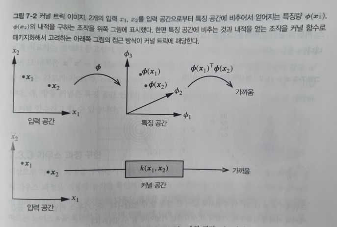

### 가우스 커널

- 커널함수의 출력은 내적결과가 가지는 특성을 만족해야 함
  - **입력이 바뀌어도 같은 결과가 나옴 $k(x, x^{'}) = k(x^{'}, x)$**

#### 가우스 커널 (Gaussian Kernel, Radial Basis Function Kernel)

$$k(x, x^{'}) = exp(-\gamma || x- x^{'}||^2)$$

- **$x^{'}=(1, 2)^T$로 고정했을 때 $x=(x_1, x_2)^T$의 값에 맞춰 가우스 커널의 값이 변화하는 모습 ($\gamma = 0.5$)**
  - $x=(1, 2)^T$의 주변으로 값이 큼 $\rightarrow$ 가우스 커널은 특징 공간에서의 거리가 작을수록 (가까울수록) 높은 커널값

```python
import numpy as np
import matplotlib.pyplot as plt
```

```python
def gaussian_kernel(x, x_prime, gamma):
    return np.exp(-gamma * np.linalg.norm(x - x_prime)**2)
```

```python
def visualize_gaussian_kernel(x_prime, gamma, x_range, y_range):
    X, Y = np.meshgrid(x_range, y_range)
    Z = np.zeros_like(X)

    for i in range(len(x_range)):
        for j in range(len(y_range)):
            x = np.array([x_range[i], y_range[j]])
            Z[i, j] = gaussian_kernel(x, x_prime, gamma)

    plt.contourf(X, Y, Z, cmap='viridis')
    plt.title('Gaussian Kernel with x_prime = (1, 2)^T and gamma = 0.5')
    plt.xlabel('X1')
    plt.ylabel('X2')
    plt.colorbar(label='Kernel Value')
    plt.scatter(x_prime[0], x_prime[1], color='red', label='x_prime')
    plt.legend()
    plt.show()
```

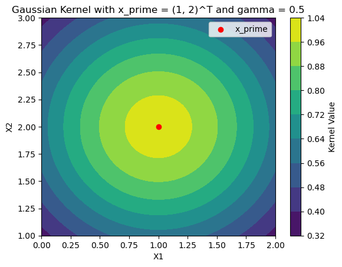

```python
x_prime = np.array([1, 2])
gamma = 0.5

x_range = np.linspace(0, 2, 100)
y_range = np.linspace(1, 3, 100)

visualize_gaussian_kernel(x_prime, gamma, x_range, y_range)
```

- 선형회귀 모델에서 다루었던 커널은 항등커널에 해당

$$k(x, x^{'}) = x^T x^{'}$$

```python
def identity_kernel(x, x_prime):
    return np.dot(x, x_prime)
```

```python
x_range = np.linspace(-4, 4, 100)
y_range = np.linspace(-4, 6, 100)
```

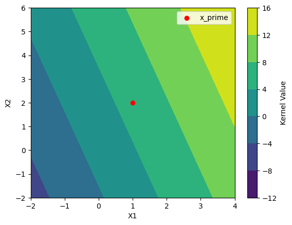

```python
def visualize_identity_kernel():
    X, Y = np.meshgrid(x_range, y_range)
    Z = np.zeros_like(X)

    for i in range(len(x_range)):
        for j in range(len(y_range)):
            x = np.array([x_range[i], y_range[j]])
            Z[i, j] = identity_kernel(x, x_prime)

    plt.contourf(X, Y, Z, cmap='viridis')
    plt.xlabel('X1')
    plt.ylabel('X2')
    plt.colorbar(label='Kernel Value')
    plt.scatter(x_prime[0], x_prime[1], color='red', label='x_prime')
    plt.xlim(-2, 4)
    plt.ylim(-2, 6)
    plt.legend()
    plt.show()

visualize_identity_kernel()
```

- **가우스 커널에서는 $x^{'}$으로부터의 거리에 대응한 동심원 형태의 등고선이 나오지만,**

  **항등 커널에서는 $x^{'}$과 직교하는 형태의 등고선이 나옴**
- **두 벡터 $x$, $x^{'}$가 이루는 각을 $\theta$라고 하면, 그 내적은 $x^T x^{'} = ||x|| ||x^{'}|| cos(\theta)$**

  $\rightarrow$ **$x^{'}$과 이루는 각도가 작아 $cos(\theta)=1$에 가깝고 길이 $||x||$가 클수록, 항등커널의 값도 커짐**

  $\rightarrow$ **항등커널은 특징 공간 안에서 같은 방향을 향하며, 길이가 길수록 큰값의 커널함수**

### 가우스 과정 구현

- 위 조건을 가진 데이터 30개 생성

$$D = \{(x_1, r_1), \dots, (x_{30}, r_{30})\}$$

```python
np.random.seed(0)
X_star = np.arange(0, 1, 0.01)
n_points = 30
```

```python
f = lambda x: 10 * x * np.sin(4 * np.pi * x)
X = np.sort(np.random.random(size=n_points))
r = f(X) + np.random.normal(0, 1, size=n_points)
```

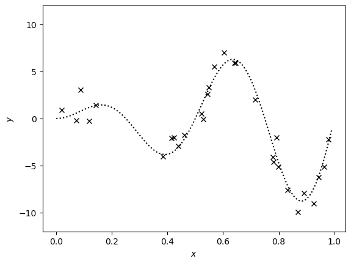

```python
plt.ylim(-12, 12)
plt.xlabel(r'$x$')
plt.ylabel(r'$y$')
plt.plot(X_star, f(X_star), color='black', linestyle='dotted')
plt.plot(X, r, 'x', color='black')
plt.show()
```

#### 커널행렬 계산

- **$K$ : 관측된 데이터의 입력 $x_1, \dots, x_{30}$끼리의 가우스 커널 계산**

$$K = \Phi \Sigma_0 \Phi^T = \begin{pmatrix} \phi(x_1)^T \\ \vdots \\ \phi(X_n)^T \end{pmatrix} \Sigma_0 (\phi(x_1), \dots, \phi(x_N))$$

이며, $K$의 $i$행 $j$열의 원소 $K_{i,j}$는 $$K_{i,j} = \phi(x_i)^T \Sigma_0 \phi(x_j)$$

$$K_{i,j} = \phi(x_i)^T (\Sigma_0^{1/2})^T \Sigma_0 \phi(x_j) \\ = (\Sigma_0^{1/2}\phi(x_i))^T (\Sigma_0^{1/2} \phi(x_j)) \\ = ς(x_i)^T ς(x_j) \\ = k(x_i, x_j)$$

```python
def gaussian_kernel(x1, x2, gamma=100):
    return np.exp(-gamma * (x1 - x2)**2)
```

```python
K = np.zeros((len(X), len(X)))
for i, xi in enumerate(X):
    for j, xj in enumerate(X):
        K[i, j] = gaussian_kernel(xi, xj)
```

```python
K.shape
```

```
(30, 30)
```

- 커널값이 큰 영역이 왼쪽 위에서 오른쪽 아래로 향하는 형태

  $\rightarrow$ **값이 가까운 입력끼리는 커널값이 크며, 값이 먼 입력끼리는 커널값이 작아짐**

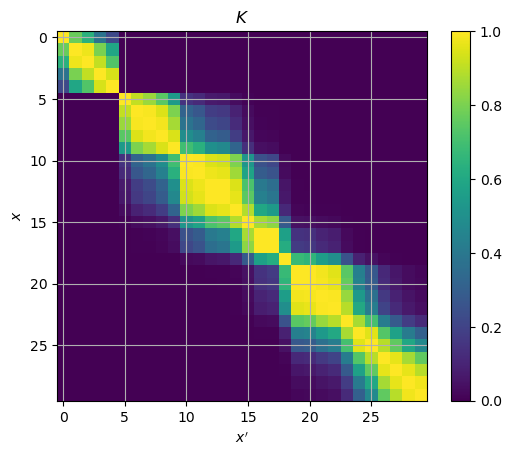

```python
plt.xlabel(r'$x^{\prime}$')
plt.ylabel(r'$x$')
plt.title(r'$K$')
plt.imshow(K)
plt.colorbar()
plt.grid(None)
plt.show()
```

- **$K_*$ : 관측된 데이터셋의 입력 포인트 $x$와, 미지의 입력 포인트 $x_*$사이의 커널값**

```python
K_star = np.zeros((len(X), len(X_star)))
for i, xi in enumerate(X):
    for j, xj_star in enumerate(X_star):
        K_star[i, j] = gaussian_kernel(xi, xj_star)
```

```python
K_star.shape
```

```
(30, 100)
```

- $X$의 요소 수가 30이지만, 미지의 입력 포인트는 100개 (`X_star`)

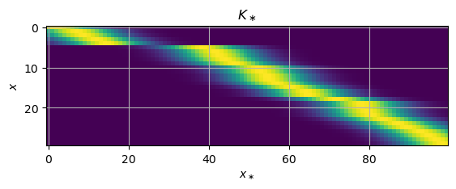

```python
plt.xlabel(r'$x_\ast$')
plt.ylabel(r'$x$')
plt.title(r'$K_\ast$')
plt.imshow(K_star)
plt.grid(None)
plt.show()
```

- **$K_{**}$ : 미지의 입력 포인트 $x_*$끼리의 커널값을 계산한 것**

```python
K_starstar = np.zeros((len(X_star), len(X_star)))
for i, xi_star in enumerate(X_star):
    for j, xj_star in enumerate(X_star):
        K_starstar[i, j] = gaussian_kernel(xi_star, xj_star)
```

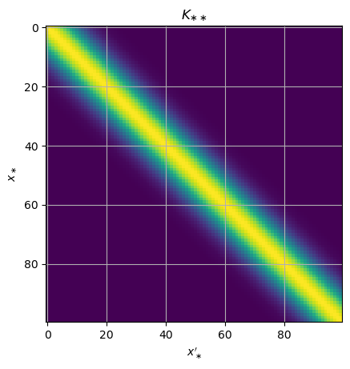

```python
plt.xlabel(r'$x_\ast^{\prime}$')
plt.ylabel(r'$x_\ast$')
plt.title(r'$K_{\ast\ast}$')
plt.imshow(K_starstar)
plt.grid(None)
plt.show()
```

#### 가우스 과정 회귀결과

- $(K + \sigma I)^{-1}$ 계산

```python
s = 1
A = np.linalg.inv(K + s * np.eye(K.shape[0]))
```

- **아래 식을 적용하여, 가우스 과정 회귀의 기댓값과 분산 계산**

$$E[f_* | X_*] = K^T_* (\sigma^2 I + K)^{-1} r \\ V[f_* | X_*] = K_{**} - K^T_* (\sigma^2 I + K)^{-1} K_*$$

```python
mu = np.dot(np.dot(K_star.T, A), r)
sigma = K_starstar - np.dot(np.dot(K_star.T, A), K_star)
```

- 데이터를 생성한 원래 함수 $f(x)$를 점선,

  기댓값 함수의 사후분포 기댓값 $E[f_* | X_*]$을 실선

  데이터셋의 관측 포인트를 x점

  사후분포 표준편차를 2배한 영역을 흐리게 칠하여 표시

  $\rightarrow$ **가우스 과정 회귀를 통해 얻어진 기댓값, 즉 회귀곡선(실선)이 데이터를 생성한 실제 함수 $f(x)$ (점선)를 따르는 모습**
  - **관측된 데이터에는 노이즈가 포함되어 있지만, 그럼에도 원래 함수를 잘 추정하는 것으로 보임**
  - **충분한 데이터를 얻지 못한 구간 $0.2 \leq x \leq 0.4$에서는 그 외 구간에 비해 표준편차의 폭이 큼**

    $\rightarrow$ **데이터를 얻지 못한 경우에는, 어떤 특정값 주변이라고 확신하지 않고, 넓은 영역에서의 가능성을 제시**

    (회귀곡선을 신뢰도와 함께 얻는 것이 베이즈 추론에 기반한 접근 방식의 특징)

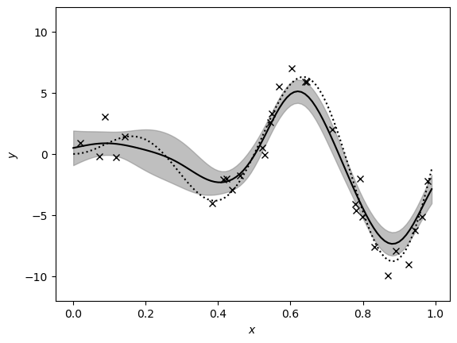

```python
plt.ylim(-12, 12)
plt.plot(X_star, f(X_star), color='black', linestyle='dotted')
plt.fill_between(X_star, mu - 2 * np.sqrt(np.diag(sigma)), mu + 2 * np.sqrt(np.diag(sigma)), alpha=0.5, color='gray')
plt.plot(X_star, mu, color='black')
plt.plot(X, r, 'x', color='black')
plt.xlabel(r'$x$')
plt.ylabel(r'$y$')
plt.show()
```

- **기댓값 함수 $f$의 사후분포를 나타내는 다차원 정규분포의 기댓값 $E[f_* | x_*]$와 분산 $V[f_* |x_*]$를 구했으므로,**

  **그 다차원 정규분포로부터 샘플링을 생성해서 회귀곡선 샘플을 시각화**

  $\rightarrow$ **$0.2 \leq x \leq 0.4$처럼 데이터가 많이 관측되지 않은 영역에서는 상대적으로 샘플의 밀도가 높지 않음**

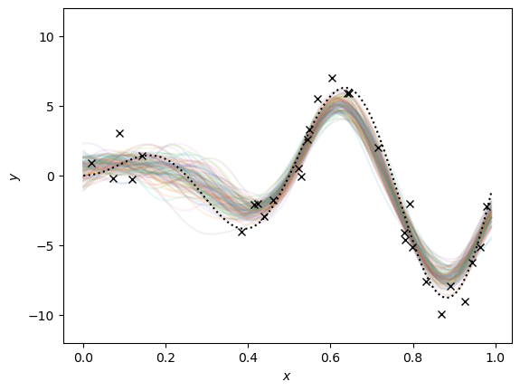

```python
plt.ylim(-12, 12)
for _ in range(100):
    plt.plot(X_star, np.random.multivariate_normal(mu, sigma), alpha=0.1)
plt.plot(X_star, f(X_star), color='black', linestyle='dotted')
plt.plot(X, r, 'x', color='black')
plt.xlabel(r'$x$')
plt.ylabel(r'$y$')
plt.show()
```

### 빠른 계산을 위한 개선

- 커널행렬 $K$, $K_*$, $K_{**}$를 구할 때, 반복문을 이용한 배열요소를 확인하고 그 사이의 커널 함숫값을 계산

  $\rightarrow$ 이는 커널행렬 정의에 기반한 직관적인 구현이지만, 솔루션의 차원이 커지면 계산속도가 늦어짐
- 솔루션 집합에서 솔루션 몇 개를 선택해서 구성한 2개의 부분 집합 $X=\{x_,1 \dots, x_N \}$과, $X^{'}=\{x^{'}_1, \dots x^{'}_M\}$

  (포함된 솔루션의 수는 각각 $N, M$)
- 2개 집합 사이의 커널행렬 $K(X, X^{'})$ 계산

$$K(X, X^{'}) = \begin{pmatrix} exp(-\gamma ||x_1 - x^{'}_1||^2) \dots exp(-\gamma ||x_1 - x^{'}_M||^2) \\ \vdots \dots \vdots \\ exp(-\gamma ||x_N - x^{'}_1||^2) \dots exp(-\gamma ||x_N - x^{'}_M||^2) \end{pmatrix} \\ =exp(-\gamma \begin{pmatrix} ||x_1 - x^{'}_1 ||^2 \dots ||x_1 - x^{'}_M ||^2 \\ \vdots \dots \vdots \\ ||x_N - x^{'}_1 ||^2 \dots ||x_N - x^{'}_M ||^2\end{pmatrix}) \\ =exp(-\gamma(\begin{pmatrix} ||x_1||^2 \dots ||x_1||^2 \\ \vdots \dots \vdots \\ ||x_N||^2 \dots ||x_N||^2 \end{pmatrix} -2 \begin{pmatrix} x^T_1 x^{'}_1 \dots x^T_1 x^{'}_M \\ \vdots \dots \vdots \\ x^T_N x^{'}_1 \dots x^T_N x^{'}_M\end{pmatrix} + \begin{pmatrix} ||x^{'}_1||^2 \dots ||x^{'}_M||^2 \\ \vdots \dots \vdots \\ ||x^{'}_1||^2 \dots ||x^{'}_M||^2 \end{pmatrix})) \\ = exp(-\gamma (P^T_X - 2Q_{X, X'} + P_{X'}))$$
$$(||x-x'||^2 = ||x||^2 - 2x^T x' + ||x'||^2)$$

이며,

$$P_X = \begin{pmatrix} ||x_1||^2 \dots ||x_N||^2 \\ \vdots \dots \vdots \\ ||x_1||^2 \dots ||x_N||^2 \end{pmatrix} \;\;\; Q_{X, X'} = \begin{pmatrix} x^T_1 x^{'}_1 \dots x^T_1 x^{'}_M \\ \vdots \dots \vdots \\ x^T_N x^{'}_1 \dots x^T_N x^{'}_M\end{pmatrix}$$

- $Q_{X, X'}$의 정의와 마찬가지로, $Q_{X, X}$와 $Q_{X', X}'$는 각각 $N\times M$과 $M\times M$의 정방행렬

  $\rightarrow$ 정방행렬의 대각성분을 나타내는 벡터를 반환하는 함수 $\delta$가 존재한다면

  $\rightarrow$ $\delta(Q_{X, X}) = (x^T_1 x_1, \dots, x^T_N x_N) = (||x_1||^2, \dots, ||x_N||^2)$이며,

  $\delta(Q_{X', X'}) = (x'^T_1 x'_1, \dots, x'^T_N x'_N) = (||x'_1||^2, \dots, ||x'_N||^2)$
- $P_X$는 $\delta(Q_{X, X})$를 행 방향으로 $M$번,

  $P_{X'}$는 $\delta(Q_{X', X'})$을 행 방향으로 $N$번 반복한 것

$$P_X = T_M(\delta(Q_{X, X})) \\ P_{X'} = T_N (\delta(Q_{X', X'}))$$$$\rightarrow K(X, X') = exp(-\gamma(T^T_M (\delta(Q_{X, X}))-2Q_{X, X'} + T_N (\delta(Q_{X', X'}))))$$

따라서 가우스 과정에 필요한 커널행렬은

$$K = K(X, X) = exp(-\gamma(T^T_M (\delta(Q_{X, X}))-2Q_{X, X} + T_N (\delta(Q_{X, X})))) \\ K_* =K(X, X_*) = exp(-\gamma(T^T_M (\delta(Q_{X, X}))-2Q_{X, X_*} + T_N (\delta(Q_{X_*, X_*})))) \\ K_{**} = K(X_*, X_{*}) = exp(-\gamma(T^T_M (\delta(Q_{X_*, X_*}))-2Q_{X_*, X_*} + T_N (\delta(Q_{X_*, X_*}))))$$

```python
gamma = 100
X = np.expand_dims(X, 0)
X_star = np.expand_dims(X_star, 0)
Q = np.dot(X.T, X)
Q_star = np.dot(X.T, X_star)
Q_starstar = np.dot(X_star.T, X_star)
```

```python
K = np.exp(-gamma * (np.tile(np.diag(Q), (X.shape[1], 1)).T - 2 * Q + np.tile(np.diag(Q), (X.shape[1], 1))))
K_star = np.exp(-gamma * (np.tile(np.diag(Q), (X_star.shape[1], 1)).T - 2 * Q_star + np.tile(np.diag(Q_starstar), (X.shape[1], 1))))
K_starstar = np.exp(-gamma * (np.tile(np.diag(Q_starstar), (X_star.shape[1], 1)).T - 2 * Q_starstar + np.tile(np.diag(Q_starstar), (X_star.shape[1], 1))))
```

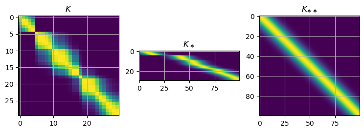

```python
plt.figure(figsize=(9, 3))
plt.subplot(1, 3, 1)
plt.title(r'$K$')
plt.imshow(K)
plt.grid(None)

plt.subplot(1, 3, 2)
plt.title(r'$K_\ast$')
plt.imshow(K_star)
plt.grid(None)

plt.subplot(1, 3, 3)
plt.title(r'$K_{\ast\ast}$')
plt.imshow(K_starstar)
plt.grid(None)
plt.show()
```

## 07.03. 최적의 색 탐색

- 슬롯머신 알고리즘이 가진 통계모델을 가우스 과정으로 변경하는 것만으로 유용한 알고리즘 구축 가능
- 색은 사람의 행동에 큰 영향을 미치는 요소 중 하나

  $\rightarrow$ 타깃 사용자에게 보여준 뒤 사용자가 반응 (행동)을 해야 알 수 있기에, 제품의 색을 바꿔보면서 A/B 테스트나 마케팅 조사를 수행

### 솔루션 공간으로서의 색공간

- 색공간의 정의 : 모든 색을 색공간으로 다루며, 색을 정량적인 값으로 나타냄 (표색계, Color System)

  $\rightarrow$ 이 표색계를 공간상에 표현한 것이 색공간

#### **RGB**

- RGB 표색계는 Red, Green, Blue의 3가지 색을 섞어서 표현

  $\rightarrow$ 빛의 삼원색에 대응하며 수치가 클수록 밝고 하얗게 표시 $\rightarrow$ 가법혼색
- 최근에는 각 색에 8비트 숫잣값을 할당해서 합계 24비트 ($2^{24}=16, 777,216$) 종류의 색을 표현
- 웹 개발에서도 RGB 각 값을 0이상 255이하의 값으로 지정하여 RGB 색공간을 이용한 색을 지정할 수 있으며,

  RGB 각 값을 16진수로 지정한 Hex코드 (예 #1E90FF)를 이용한 색 지정 방법을 사용
- 하지만 RGB 색공간은 그 숫잣값과 실제 색의 관계가 그다지 작관적이지 않은 단점 존재

[figure not shown]

#### HSV & HLS

- **HSV 색공간은 색상(Hue), 채도(Saturations), 명도 (Value)라는 3개 성분을 이용하여 색을 표현**
  - 색상은 색의 종류, 채도는 선명함, 명도는 밝기를 의미
  - 색상은 원으로 나타내며, 어떤 색은 그 위의 점으로 표현 $\rightarrow$ 어떤 색의 색상은 각도로 나타나며 0도에서 360도의 값을 가짐
  - 채도와 명도는 백분율로 나타나며 0%부터 100%의 값으로 표현
- HSV와 HLS 표색계의 장점은 가법혼색을 생각하지 않고도 '어떤 색을', '어느 정도 탁하게', '어느 정도 밝게' 할지 나타내는 파라미터를 조합해서 색을 지정할 수 있다는 것
  - 예) 카스테라 표면의 색이 머리에 떠올랐을 때, 먼저 노란색의 색상을 선택하고, 그 지점에서 깊이로 명도를 선택한 뒤, 채도를 약간 내려서 탁하게 만드는 식으로 색상 설정

  $\rightarrow$ 빨강과 초록의 가법혼색이 노랑인 것을 상기하지 않아도 됨
- **HLS 색공간은 색상(Hue), 휘도(Lightness), 채도(Saturations)의 3가지 성분을 이용하여 색을 표현**
  - HLS 색공간도 HSV 색공간과 마찬가지로 먼저 색상을 이용해 색의 종류를 결정하고, 그 선명함과 밝기를 조정함으로써 가법혼색을 몰라도 색을 지정

*HLS, HSV 표색계*

[figure not shown]

- HSV 색공간에서 원색은 명도 (Value) 100% 영역에서 나타나는 것에 비해 HLS 색공간에서는 휘도(Lightness) 50% 영역에 대응

  색의 변화를 기준으로 해서 색공간을 다시 그리면, 각각 원뿔형 & 쌍원뿔형 색공간으로 나타낼 수 있음

[figure not shown]

#### 색상 최적화

- 색을 최적화하기 위해서는, 2차원에 다양한 색이 포함되는 색공간을 사용

  $\rightarrow$ **3차원의 공간중, 한 차원의 값을 고정하여 2차원으로 만든 것을 이용**

  $\rightarrow$ **HLS, HSV 색공간은 색상 차원만 고정하지 않으면 다양한 색의 종류를 마음대로 표현할 수 있음**

  $\rightarrow$ **그중 채도를 100%로 고정하면 선명한 색을 2차원 팔레트 위에 배치할 수 있음**

  $\rightarrow$ **HLS 색공간은 휘도차원의 값에 따라 검정색에서 흰색까지 다룰 수 있으므로, 채도를 100%로 고정해도 어두운 색부터 밝은 색까지 2차원에 표현**

  $\rightarrow$ HLS 색공간에서 채도를 100%로 고정한 부분 공간을 솔루션 공간으로 채용
- `matplotlib`에서는 RGB 값을 전달해야 하므로,

  HLS의 색상 및 휘도를 전달하면, 채도 100% 기준의 RGB 값을 반환하여 시각화

```python
import colorsys
```

```python
N = 30
X_im = np.zeros((N, N, 2))
rs = []
xs = []
```

```python
for i in range(N):
    for j in range(N):
        X_im[i, j, 0] = i / N # 색상
        X_im[i, j, 1] = j / N # 휘도
```

```python
hl_to_rgb = lambda x: colorsys.hls_to_rgb(x[0], x[1], 1)
X_rgb = np.apply_along_axis(hl_to_rgb, -1, X_im)
```

- **해당 색상 솔루션 공간의 특징**
  - **검정색과 흰색이 양끝에 넓게 나타남** : HLS 색공간에서는 휘도가 극단적으로 작거나 매우 큰 곳이 검은색 및 흰색으로 수렴
  - **빨간색이 위쪽 끝과 아래쪽 끝 양쪽에 나타남**

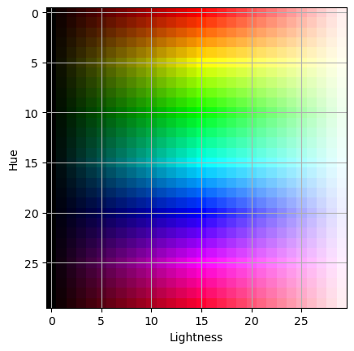

```python
plt.imshow(X_rgb)
plt.grid(None)
plt.xlabel('Lightness')
plt.ylabel('Hue')
plt.show()
```

## 07.04. GP-UCB (Gaussian Process - Upper Confidence Bound Algorithm)

- GP-UCB 알고리즘은 가우스 과정에 의해 얻어지는 기댓값 함수의 사후분포의 기댓값과 분산을 기반으로 UCB를 산출하고,

  UCB값이 최대가 되는 솔루션을 순차적으로 선택하는 알고리즘

  $\rightarrow$ **LinUCB 알고리즘의 베이즈 선형회귀를 가우스 과정으로 대체한 것**
- UCB 값은 기대치와 표준편차의 정수배로 산출

  $\rightarrow$ 즉, 어떤 솔루션 $x_* \in X$의 UCB 값 $UCB_{X_*}$를 다음과 같이 계산

$$UCB_{x_*} = E[f_* | x_*] + \alpha \sqrt{V[f_*|x_*]} = k^T_* (\sigma^2 I + K)^{-1} r + \alpha\sqrt{k_{**} - k^T_* (\sigma^2 I + K)^{-1} k_*}$$

- **베이즈 최적화의 맥락에서, 이 UCB 값처럼 선택해야할 솔루션을 가리키는 함수를 획득함수 (Acauisition Function)이라고 함**

  베이즈 최적화에서는 이 획득함수가 최대가 되는 솔루션을 순차적으로 선택하면서 탐색을 진행

  $\rightarrow$ 따라서, 이 획득함수의 구현이 각각의 베이즈 최적화 기법을 특징지음

### GP-UCB 구현

- 미지의 입력 포인트의 집합 $X_*$에 해당하는 `X_Star` 정의
- 솔루션 공간에 포함된 모든 솔루션의 입력 포인트에 관심이 있으므로, 앞에서 정의한 솔루션 공간 `X_im`을 솔루션의 집합으로 늘어놓음

```python
X_star = X_im.reshape((N * N, 2)).T
```

```python
X_star.shape
```

```
(2, 900)
```

#### GP-UCB 에이전트

- `self.xs` : 지금까지 선택한 솔루션의 이력
- `self.rs` : 그에 대응해서 얻은 평갓값의 이력
- `self.gamma` : 가우스 커널의 상수 $\gamma > 0$
- `self.s` : 평갓값으로 가정한 분산 $\sigma^2$
- `self.alpha` : UCB 값을 산출할 때 표준편차에 곱하는 상수 $\alpha$
- 미지의 입력포인트 $X_*$은 미리 계산 가능
  - `self.Q_starstar` : $Q_{x_*, x_*}$ $\rightarrow$ 커널행렬 $K_*$와 $K_{**}$ 계산에 활용
  - `self.K_starstar` : 미지의 입력 포인트끼리의 커널행렬 $K_{**}$
- `self.my` : 기댓값 함수의 사후분포 기댓값 $E[f_* |X_*]$
- `self.sigma` : 기댓값 함수의 사후분포 분산 $V[f_* |X_*]$

  $K^T_* (\sigma I + K)^{-1}$의 초기 기댓값은 0, 분산은 $K_{**}$ (초기에는 관측된 솔루션이 없으므로 $X$, $K$, $K_*$는 모두 공행렬이기 때문)

```python
class GPUCBAgent(object):

    def __init__(self):
        self.xs = []
        self.rs = []
        self.gamma = 10
        self.s = 0.5
        self.alpha = 2

        self.Q_starstar = X_star.T.dot(X_star)
        self.K_starstar = np.exp(-self.gamma * (np.tile(np.diag(self.Q_starstar), (X_star.shape[1], 1)).T
                                                - 2 * self.Q_starstar
                                                + np.tile(np.diag(self.Q_starstar), (X_star.shape[1], 1))))
        self.mu = np.zeros(self.K_starstar.shape[0])
        self.sigma = self.K_starstar

    # 기댓값 함수와 사후분포의 기댓값과 분산으로부터 입력포인트 x*의 UCB 값을 이용해 산출
    def get_arm(self):
        ucb = self.mu + self.alpha * np.diag(self.sigma)
        return X_star[:, np.argmax(ucb)], ucb # UCB 값이 최대가 되는 솔루션을 반환

    # 제사한 솔루션과 그에 대한 평갓값을 입력으로 하여 커널행렬 및 사후분포를 갱신
    def sample(self, x, r):
        self.xs.append(x)
        self.rs.append(r)

        X = np.array(self.xs).T
        Q = X.T.dot(X)
        Q_star = X.T.dot(X_star)
        K = np.exp(-self.gamma * (np.tile(np.diag(Q), (X.shape[1], 1)).T - 2 * Q + np.tile(np.diag(Q), (X.shape[1], 1))))
        K_star = np.exp(-self.gamma * (np.tile(np.diag(Q), (X_star.shape[1], 1)).T
                                       - 2 * Q_star
                                       + np.tile(np.diag(self.Q_starstar), (X.shape[1], 1))))
        A = np.linalg.inv(self.s + np.identity(K.shape[0]) + K)
        self.mu = K_star.T.dot(A).dot(self.rs)
        self.sigma = self.K_starstar - K_star.T.dot(A).dot(K_star)
```

### 동작 확인

- 실제 웹최적화에서는 사용자의 반응을 통해 학습
- 지금은 지정된 색을 정답, 즉 최적 솔루션으로 간주하고 이를 탐색하는 문제로 전환

  $\rightarrow$ 대화형 최적화를 이용해 사람이 생각한 색을 대화를 통해 도출

  **(원하는 색이 녹색이라고 가정)**
- **대화형 최적화에서 평가자가 에이전트에 주는 평갓값은 -2 (완전히 다름), -1 (다소 다름), 0 (어느 쪽이라고 말할 수 없음), 1 (약간 비슷함), 2 (완전히 같음)**

  $\rightarrow$ 이후 피험자 (개인)와 컴퓨터의 대화에 따른 최적화가 아닌, 사용자와 웹사이트의 대화에 의한 최적화로 전환 가능
- 에이전트와 제시된 솔루션 $x$ 및 획득함수 $f$를 전달

```python
from mpl_toolkits.axes_grid1 import ImageGrid
```

```python
def visualize(agent, x, f):
    vmax = 1.6
    vmin = -1.6
    contour_linewidth = 0.6
    contour_fontsize = 6
    contour_levels = np.linspace(-2, 2, 17)
    fig = plt.figure()

    grid = ImageGrid(fig, 211, nrows_ncols=(1, 2), axes_pad=0.1)
    grid[0].imshow(X_rgb)
    cs = grid[0].contour(f.reshape(N, N), levels=contour_levels, colors='white', linewidths=contour_linewidth)
    grid[0].clabel(cs, inline=1, fontsize=contour_fontsize)
    grid[0].plot(x[1] * N, x[0] * N, '*', markersize=20, color='yellow', markeredgecolor='black')
    grid[0].set_title('Solution space')
    grid[0].set_xticklabels([])
    grid[0].set_yticklabels([])
    grid[1].imshow(np.tile(hl_to_rgb(x), (N, N, 1)))
    grid[1].set_title('Proposed color')
    grid[1].set_xticklabels([])
    grid[1].set_yticklabels([])
    grid = ImageGrid(fig, 212, nrows_ncols=(1, 3), axes_pad=0.2, share_all=True, label_mode='L', cbar_location='left', cbar_mode='single')

    im = grid[0].imshow(agent.mu.reshape(N, N), vmin=vmin, vmax=vmax)
    cs = grid[0].contour(agent.mu.reshape(N, N), levels=contour_levels, colors='white', linewidths=contour_linewidth)
    grid[0].clabel(cs, inline=1, fontsize=contour_fontsize)
    grid[0].set_title(r'$\mu$')
    grid.cbar_axes[0].colorbar(im)
    grid[1].imshow(np.diag(agent.sigma).reshape(N, N), vmin=vmin, vmax=vmax)
    cs = grid[1].contour(np.diag(agent.sigma).reshape(N, N), levels=contour_levels, colors='white', linewidths=contour_linewidth)
    grid[1].set_title(r'$diag(\Sigma)$')
    grid[1].clabel(cs, inline=1, fontsize=contour_fontsize)
    grid[2].imshow(f.reshape(N, N), vmin=vmin, vmax=vmax)
    cs = grid[2].contour(f.reshape(N, N), levels=contour_levels,
                       colors='black', linewidths=contour_linewidth)
    grid[2].clabel(cs, inline=1, fontsize=contour_fontsize)
    grid[2].set_title('Acquisition function')
    plt.show()
```

- 상단 왼쪽에 그려진 것은 솔루션 공간과 선택된 솔루션
  - HLS 색공간에서 채도를 100%로 고정한 채 색상과 휘도를 변경했을 때의 색 변화를 솔루션 공간으로 표현
  - GP-UCB 에이전트에 의해 제시된 솔루션을 위치를 별 마크로 표시
- 상단 오른쪽은 제시된 솔루션
- 하단 왼쪽에는 기댓값 함수의 사후분포 기댓값 $E[f_* |x_*]$,

  하단 가운데는 분산 $V[f_* |x_*]$의 대각성분

  하단 오른쪽에는 획득함수 (UCB 값)

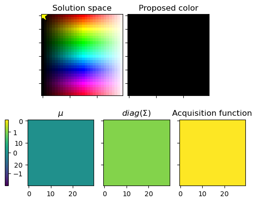

```python
agent = GPUCBAgent()
x, ucb = agent.get_arm()
visualize(agent, x, ucb)
```

- **에이전트가 가장 제시한 솔루션은 (색상, 휘도) = (0, 0)에 대응하는 검은색**

  $\rightarrow$ **현재 원하는 색은 녹색이기에, -2의 평갓값을 부여**

  $\rightarrow$ **-2의 평갓값을 부여한 그림 왼쪽 위의 (색상, 휘도) = (0, 0)에 해당하는 포인트의 UCB 값이 다른 영역에 비해 낮아짐**

  $\rightarrow$ **반대쪽인 오른쪽 아래의 솔루션이 UCB 값이 최대가 되어 다음 솔루션으로 제시**

  $\rightarrow$ **상단 오른쪽의 색을 봐도 이전 색보다는 흰색에 가까워진 색이 선택**
- **하단 왼쪽 (기댓값 함수의 사후분포 기댓값)도 평갓값을 부여한 상단 왼쪽의 솔루션 주변의 값이 낮아짐**

  $\rightarrow$ **초기화 시점에서는 모든 영역에 대한 기댓갑싱 0이었지만, 이 영역에서는 음의 값이 주어진 것을 알 수 있음**

  $\rightarrow$ **앞에서 사후분포에 음의 피드백 효과가 나타남**
- **하단 가운데 (기댓값 함수의 사후분포 분산)도 마찬가지로 상단 왼쪽 주변의 값이 낮아짐**

  $\rightarrow$ **이는 평갓값이 주어진 결과 이 영역에서의 불확실성이 사라졌기 때문**

  $\rightarrow$ **평갓값이 -2가 아닌 2를 입력받아도 동일한 결과 일 것**
- **하단 오른쪽 (획득함수)도 상단 왼쪽 솔루션을 중심으로 값이 낮아짐**

  $\rightarrow$ **UCB 값은 사후분포의 기댓값에 분산의 상수배를 더한 것이기 때문**

```python
agent.sample(x, -2)
```

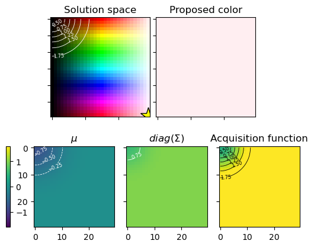

```python
x, ucb = agent.get_arm()
visualize(agent, x, ucb)
```

#### **반복해서 평갓값 부여**

- 획득함수인 UCB 값의 등고선을 보면, 그 결과를 반영해 네 모서리를 중심으로 값이 낮아짐
- 이번에는 극단적으로 어두운 색이나 밝은 색이 아닌, 솔루션 공간의 중심에 있는 색이 제시

  $\rightarrow$ 이전 제시 색상에 비해서는 괜찮아짐

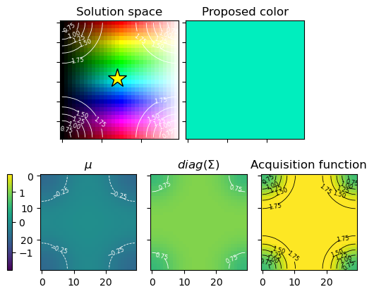

```python
agent.sample(x, -2)
x, ucb = agent.get_arm()
agent.sample(x, -2)
x, ucb = agent.get_arm()
agent.sample(x, -2)
x, ucb = agent.get_arm()
visualize(agent, x, ucb)
```

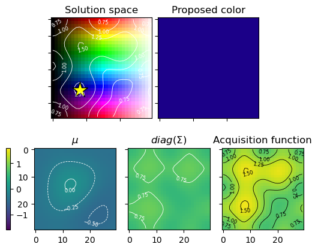

```python
agent.sample(x, -1)
x, ucb = agent.get_arm()
agent.sample(x, -2)
x, ucb = agent.get_arm()
agent.sample(x, -2)
x, ucb = agent.get_arm()
agent.sample(x, -2)
x, ucb = agent.get_arm()
agent.sample(x, -2)
x, ucb = agent.get_arm()
agent.sample(x, -2)
x, ucb = agent.get_arm()
visualize(agent, x, ucb)
```

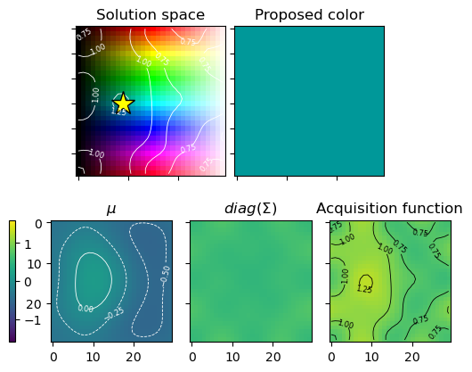

```python
agent.sample(x, -1)
x, ucb = agent.get_arm()
agent.sample(x, -1)
x, ucb = agent.get_arm()
agent.sample(x, -2)
x, ucb = agent.get_arm()
visualize(agent, x, ucb)
```

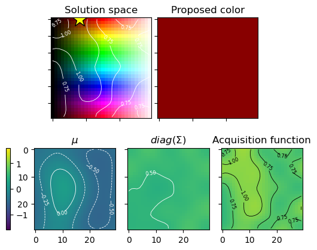

```python
agent.sample(x, -1)
x, ucb = agent.get_arm()
agent.sample(x, -1)
x, ucb = agent.get_arm()
agent.sample(x, -2)
x, ucb = agent.get_arm()
visualize(agent, x, ucb)
```

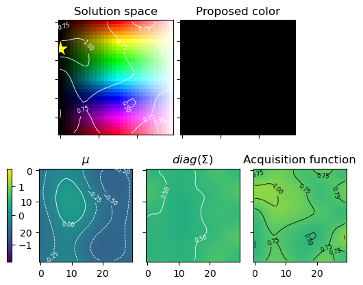

```python
agent.sample(x, -1)
x, ucb = agent.get_arm()
agent.sample(x, -1)
x, ucb = agent.get_arm()
agent.sample(x, -2)
x, ucb = agent.get_arm()
visualize(agent, x, ucb)
```

- 반복적인 평갓값 부여를 통해, 녹색계열의 색상 도출

  $\rightarrow$ **탐색을 시작한 단계에서는 솔루션의 UCB 값이 같으므로, 최초의 솔루션으로부터 (색상, 휘도) = (0, 0)이 선택**

  $\rightarrow$ **탐색 초기, 솔루션 공간의 네 모서리를 탐색하고, 그 결과로 검은색이나 흰 색 등의 극단적인 색이 제시됨**

  $\rightarrow$ **탐색 경로를 보면, 솔루션 공간의 끝에서 점점 녹색 영역으로 접근함으로써, 소위 바깥 해자 (moat)를 메우는 움직임**

  $\rightarrow$ **초기에는 솔루션 공간을 제약없이 탐색하고, 점점 유망한 솔루션에 가까워짐에 따라 효율이 좋은 탐색이 갖추어야 할 다양화와 집중화를 실현**

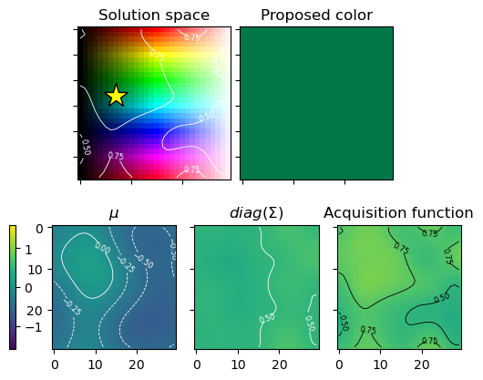

```python
agent.sample(x, -1)
x, ucb = agent.get_arm()
agent.sample(x, -1)
x, ucb = agent.get_arm()
agent.sample(x, -2)
x, ucb = agent.get_arm()
visualize(agent, x, ucb)
```

## 07.05. GP-TS (Gaussian Process Thompson Sampling Algorithm)

- **가우스 과정을 톰슨 샘플링에 적용**
- **가우스 과정에 기반해, 사후분포로부터 각 솔루션의 함숫값을 샘플링해서 그것이 최대가 되는 솔루션을 제시**

#### GP-TS 에이전트

- 톰슨 샘플링에서는 UCB 구간이 필요없음

  $\rightarrow$ **GP-UCB 알고리즘에서는 UCB 값을 계산해서 그 값이 최대가 되는 솔루션을 선택했었지만,**

  **GP-TS 알고리즘에서는 가우스 과정에서 얻은 사후분포로부터 함숫값 $f$를 샘플링 `np.random.multivariate_normal`**

  $\rightarrow$ **이 함숫값이 최대가 되는 솔루션을 반환**

```python
class GPTSAgent(object):
    def __init__(self):
        self.xs = []
        self.rs = []
        self.gamma = 10
        self.s = 0.5
        self.Q_starstar = X_star.T.dot(X_star)
        self.K_starstar = np.exp(-self.gamma * (np.tile(np.diag(self.Q_starstar), (X_star.shape[1], 1)).T
                                                - 2 * self.Q_starstar
                                                + np.tile(np.diag(self.Q_starstar), (X_star.shape[1], 1))))
        self.mu = np.zeros(self.K_starstar.shape[0])
        self.sigma = self.K_starstar

    # 가우스 과정에서 얻은 사후분포로부터 함숫값 f를 샘플링
    def get_arm(self):
        f = np.random.multivariate_normal(self.mu, self.sigma)
        return X_star[:, np.argmax(f)], f # 함숫값 f가 최대가 되는 솔루션 반환

    def sample(self, x, r):
        self.xs.append(x)
        self.rs.append(r)
        X = np.array(self.xs).T

        Q = X.T.dot(X)
        Q_star = X.T.dot(X_star)
        K = np.exp(-self.gamma * (np.tile(np.diag(Q), (X.shape[1], 1)).T
                                  - 2 * Q + np.tile(np.diag(Q), (X.shape[1], 1))))
        K_star = np.exp(-self.gamma * (np.tile(np.diag(Q), (X_star.shape[1], 1)).T
                                       - 2 * Q_star + np.tile(np.diag(self.Q_starstar), (X.shape[1], 1))))
        A = np.linalg.inv(self.s + np.identity(K.shape[0]) + K)
        self.mu = K_star.T.dot(A).dot(self.rs)
        self.sigma = self.K_starstar - K_star.T.dot(A).dot(K_star)
```

- **최초상태에서는 평갓값에 관한 정보가 아무것도 없음 $\rightarrow$ 기댓값 및 분산이 모든 솔루션에 관해 균일한 다차원 정규분포로부터 난수가 발생**

  $\rightarrow$ **반복적인 평갓값 부여를 통하여 사후분포가 업데이트 되고, 그것을 반영한 다차원 정규분포 (획득함수)가 샘플링**

  $\rightarrow$ **최종적인 사후분포의 기댓값 및 분산의 등고선을 보면, 하늘색 및 녹색에 걸친 영역의 기댓값이 큼**

  $\rightarrow$ **샘플링된 획득함수에 영향을 주며, 이 영역의 솔루션을 선택할 확률이 증가**

  $\rightarrow$ **탐색의 집중화를 실현**

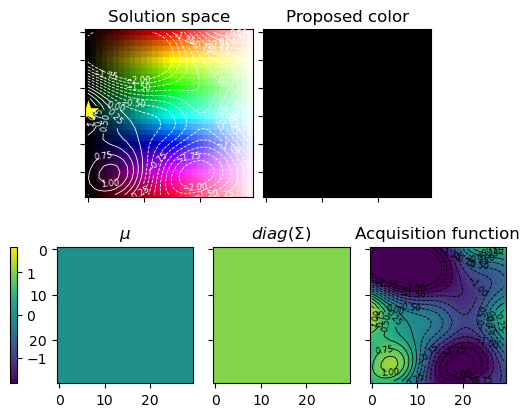

```python
np.random.seed(0)
agent = GPTSAgent()
x, f = agent.get_arm()
visualize(agent, x, f)
```

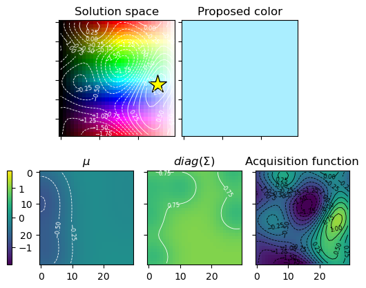

```python
agent.sample(x, -2)
x, f = agent.get_arm()
agent.sample(x, -1)
x, f = agent.get_arm()
agent.sample(x, -1)
x, f = agent.get_arm()
agent.sample(x, -1)
x, f = agent.get_arm()
agent.sample(x, -2)
x, f = agent.get_arm()
agent.sample(x, -2)
x, f = agent.get_arm()
visualize(agent, x, f)
```

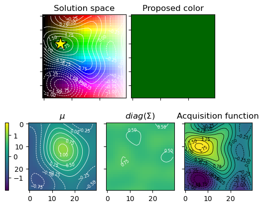

```python
agent.sample(x, -1)
x, f = agent.get_arm()
agent.sample(x, 1)
x, f = agent.get_arm()
agent.sample(x, -2)
x, f = agent.get_arm()
agent.sample(x, -2)
x, f = agent.get_arm()
agent.sample(x, -2)
x, f = agent.get_arm()
agent.sample(x, 1)
x, f = agent.get_arm()
visualize(agent, x, f)
```

## 07.06. GP응용의 주의점

- **가우스 과정을 응용할 때 병목이 되는 것은 역행렬의 계산**
  - 사후분포의 기댓값과 분산을 산출하는 식에 $(\sigma^2 I + K)^{-1}$의 계산이 포함

  $\rightarrow$ **가우스 커널 $K$은 $N\times N$ 의 행렬이므로, 데이터셋에 포함된 데이터 포인트의 수가 증가할수록 커짐**

  $\rightarrow$ **이 역행렬의 계산에 필요한 계산량 또한 데이터 증가에 따라 커짐**

  $\rightarrow$ **웹 최적화나 대화형 최적에 가우스 과정을 응용할 때, 평갓값이 적은 초반에는 문제가 없지만, 충분한 수의 평갓값이 모이면 계산량이 과도하게 증가**

  $\rightarrow$ **평갓값이 주어질 때마다 사후분포를 업데이트하는 것은 용이하지 않으며, 솔루션 제시후 일정한 간격을 두고 사후분포를 갱신**
  - **GP-UCB 알고리즘은 결정적 알고리즘이기에, 사후분포를 업데이트하지 않는 한, 제시한 솔루션은 하나로 결정. 따라서 사후분포를 업데이트하지 않는 한, 제시한 솔루션은 하나**
  - **GP-TS 알고리즘은 사후분포를 업데이트하지 않더라도 매번 난수를 기반으로 솔루션을 제시하는 확률적 알고리즘이므로, 비동기적 구현이라 할지라도, 보다 다채로운 솔루션의 제시를 기반으로 동작**

## 07.07. 웹최적화의 미래

### 단기적인 평가와 장기적인 평가

- **즉각적인 반응 : 버튼의 클릭이나 페이지 체류시간 등 사용자가 웹사이트를 방문했을 때의 동작에서 측정**
  - 제품을 소개하는 랜딩 페이지, 소프트웨어 다운로드 페이지 등에서는 그 위치에서 사용자의 행동을 일으키는 것이 중요
- **장기적인 반응**
  - 검색 서비스, 메일 서비스 등, 사용자가 일상적으로 이용하는 도구의 측면이 강한 웹

  $\rightarrow$ **즉각적인 반응에만 착안한 최적화를 실행시 잘못된 결과가 발생 가능**
  - 검색 서비스는 사용자의 검색 쿼리에 맞춰, 적절한 검색결과를 표시하는 동시에, 검색쿼리에 어울리는 검색광고를 표시

  $\rightarrow$ 표시하는 광고 수가 늘어나면, 그만큼 사용자의 눈에 들어오는 광고도 늘어나므로, 단기적으로는 광고 클릭 수가 증가

  $\rightarrow$ 그러나 이는 사용자 체험을 저하시킬 위험이 존재 (품질이 낮은 광고, 검색 정보 접근이 어려워짐 등)

  $\rightarrow$ 이를 방지하기 위해, 단기적인 사용자의 반응에 기반한 지표가 아닌, 사용자의 반복율 및 이탈률 등의 오랜 기간에 걸쳐 측정되는 지표에 주목

  $\rightarrow$ 하지만 이는 최적화의 속도를 저하시킬 수 있음

  $\rightarrow$ 솔루션의 특성으로부터 장기간의 지표를 예측하는 머신러닝 모델 구축

  ```
    - 2015년 구글, 검색 연동 광고 표시 방법의 최적화 연구 : 검색결과에 많은 광고를 표시했을 떄 단기적으로 광고 클릭수가 증가하여 수익이 증가하지만, 장기적으로 서비스 이탈이 증가

    - 100개 이상의 실험결과를 이용하여 단기적으로 측정할 수 있는 지표로부터 장기적인 광고 클릭률을 예측하는 머신러닝 모델 구축 $$\text{장기적인 수익성} = \text{단기적인 수익성} + \beta_1 x_{\text{검색품질 & 광고 관련성의}} + \beta_2 x_{\text{광고대상 랜딩 페이지의 품질}}$$
  ```

### 반복 사용자를 고려한 최적화

- **학습 : 사용자가 웹사이트에 여러 차례 방문함으로써 습득한 사용법이나 감각**
  - 도구로서의 측면이 강한 웹사이트인 경우, 학습효과가 중요
- 새로운 UI를 통하여 서비스를 이용하기 시작한 신규 사용자는 사전 지식이 없기에, 비교적 손쉽게 사용자를 습득할 수 있을 것이라고 생각할 수 있음

  $\rightarrow$ 해당 웹사이트에 처음 접속한 신규 사용자와, 반복 사용자는 분명히 다른 상태를 가지고 있음

  $\rightarrow$ 강화학습 (Reinforcement Learning) 적용
  - 각 시점 $t$에서 어떤 행동 $a_t$를 일으켜 얻을 수 있는 보상 $r_t$의 누적을 최대화하여, 각 시점에서의 상태 $s_t$, 행동 $a_t$를 얻고 상태변화 $s_t \rightarrow$ $s_{t+1}$를 고려

### 솔루션 공간 디자인

- 혁신적인 솔루션을 만들어내기 위해서는 폭넓은 솔루션 공간을 채용해야 하지만, 폭넓은 솔루션 공간을 채용하면 탐색이 곤란하게 되는 Trade-Off 관계가 존재

#### 구조 최적화

- 구조 최적화에서는 솔루션 공간에 포함된 모든 인공물의 솔루션에 대해 역학 시뮬레이션을 적용해, 강도나 경고성 등의 목적 함수를 최적으로 하는 솔루션을 탐색
- 구조 최적화 접근 방식은 인공물의 솔루션을 표현하는 방법에 따라 크게 **길이 최적화**, **형태 최적화**, **토폴로지 최적화** 3가지로 구분
1. **길이 최적화 : 대상이 되는 인공물의 길이를 변수로 보고 목적에 맞는 최적의 기능을 가진 설계를 구함**
- 길이의 정의는 형태에 의존하므로, 인공물의 형태가 미리 제약으로 주어져야 함
- 길이 최적화에서는 크게 형태를 변화시키는 것과 같은 솔루션을 만들어 낼 수 있음
2. **형태 최적화 : 인공물 형태의 경계를 변수로 다룸**
- 길이를 정의할 필요가 없어 솔루션 표현이 유연함
- 이전까지는 생각하지 못한 설계를 도출할 가능성 존재
- 다만 최적화의 난이도가 증가
3. **토폴로지 최적화 : 인공물의 픽셀 또는 복셀의 집합으로 표현**
- 형태 최적화로도 유연한 솔루션 표현이 가능하지만, 경계의 수를 지정해야 함

  $\rightarrow$ 인공물이 가진 구멍 수를 늘리는 것과 같은, 토폴로지를 바꾸는 것과 같은 조작은 할 수 없음
- 토폴로지 최적화는 인공물을 작은 요소의 집합으로 표현 $\rightarrow$ 경계수가 변화하는 경우에도 대응가능하며, 더 유연한 솔루션의 표현이 가능

#### 체커보드 (Checker Board)

- 유연한 솔루션 표현이 가능한 만큼, 실행 불간으한 솔루션이 나타날 확률도 증가
- 솔루션 표현력이 커질수록, 현실문제에 대한 제한을 엄격하게 고려해야 함

  $\rightarrow$ 넓은 솔루션 공간을 대상으로 현실적인 시간 안에 최적화하기 위하여, 하나의 솔루션 공간을 보다 차원이 적은 특성공간으로 압축

  $\rightarrow$ **가변 오토인코더 (VAE)는 데이터의 차원 압축을 실현**

#### VAE

- 입력 데이터를 저차원의 특성공간으로 압축하는 인코더와, 특성으로부터 데이터를 복원하는 디코더로 구성, 인코더와 디코더를 학습 데이터로부터 획득하는 구조가 오토인코더
- 가변 오토인모더는 특성이 다차원 정규분포를 따르는 성질을 설정 $\rightarrow$ 학습 결과 얻을 수 있는 특성공간의 성질이 좋으며, 2개 특성량의 내점에 있는 특성에서도 유용한 데이터를 만들 수 있음
- MNIST는 28픽셀의 정사각형 이미지 데이터
- 만약 $28 \times 28=784$개의 픽셀이 각각 흰색 혹은 검은색으로 칠해져 있다면,

  변이 (Variation)은 약 $2^{784} \simeq 10^{236}$가지에 이르며, 무작위로 784개의 픽셀을 채워서 숫자처럼 보이는 이미지가 만들어 지는 경우는 극히 드뭄

  $\rightarrow$ VAE를 이용하여 얻은 특성공간에서는 대부분이 숫자로 보임

  $\rightarrow$ 즉, 이 공간을 대상으로하면 이미지 안에서 효율적으로 목적한 이미지를 탐색할 수 있음

  $\rightarrow$ 이를 통하여 막대한 솔루션 후보를 필터링 가능

[figure not shown]